# Introduction to TreeHeatmap

Ruizhu HUANG

Institute of Molecular Life Sciences, University of Zurich.  
SIB Swiss Institute of Bioinformatics.

30 October 2020

#### Package

TreeHeatmap 0.1.0

# Contents

```r
suppressPackageStartupMessages({
  library(TreeHeatmap)
  library(ggtree)
  library(ggplot2)
  library(ggnewscale)
  library(dplyr)
})
```

# 1 The toy data

The toy data contains a matrix (`count`) and a tree (`toytree`). The `toytree` is visualized with *ggtree*. The label and numeric id of nodes are labeled as red and blue texts, respectively.

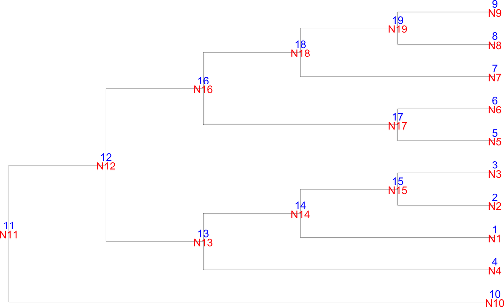

```r
data("toydata")
toytree <- toydata$toytree

(fig_tree <- ggtree(toytree, branch.length = "none", size = 0.1) +
  geom_text(aes(label = label), color = "red", vjust = 0.6) +
  geom_text(aes(label = node), color = "blue", vjust = -0.6) )
```

The matrix `count` has 10 rows and 8 columns. Each row corresponds to a leaf of the tree. The row name is the same to the leaf name.

```r
(count <- toydata$count)
```

```
##     S1 S8 S3 S2 S5 S6 S4 S7
## N1   3  7  0  3  6  8  1  5
## N2   0  7  0  0  6  6  2  3
## N3   2  6  1  1  7  5  1  8
## N4   4  4  5  6  8  7  5  8
## N5   7 11  6  6  7  3  7  7
## N6   6  4  5  5  3  6  2  6
## N7   6  2  8  7  6  3  8  4
## N8   9  1  9  8  4  2  9  2
## N9   9  3 11 11  1  2  8  3
## N10  4  5  5  3  2  8  7  4
```

`count` is visualized in the heatmap by using `geom_th_heatmap`.

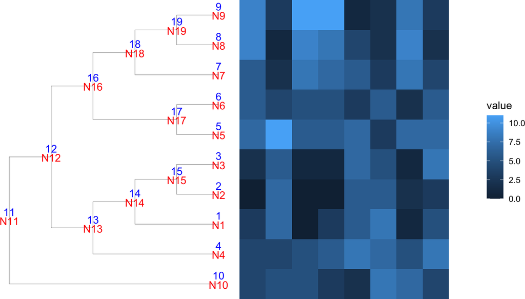

```r
fig_tree +
  geom_th_heatmap(th_data = count, name = "hm1", gap = 0.5)
```

We further cluster columns of the heatmap via `cluster_column = TRUE` and show the column tree with `show_coltree = TRUE`. The gap between the column tree and the heatmap is `gap_coltree = 0.1`. The line size and the color of the column tree are specified by `size_coltree = 0.5` and `color_coltree = "red"`, respectively. The height of the column tree is adjusted via `rel_height_coltree`.

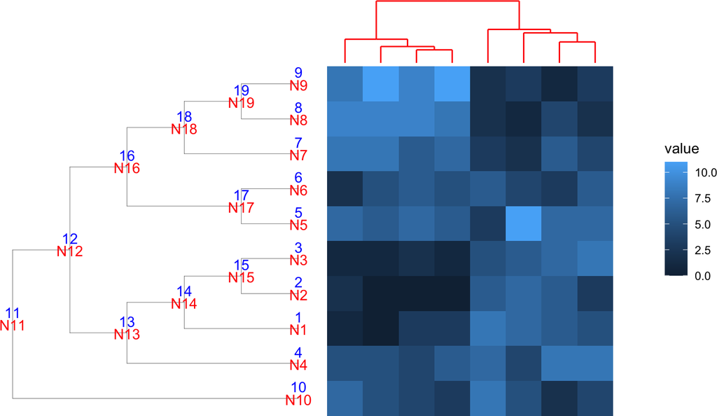

```r
fig_tree +
  geom_th_heatmap(th_data = count, name = "hm1", gap = 0.5,
                  cluster_column = TRUE, show_coltree = TRUE,
                  gap_coltree = 0.1, color_coltree = "red",
                  size_coltree = 0.5, rel_height_coltree = 0.1)
```

# 2 Display heatmaps

It is possible to align the heatmap to an arbitary level of the tree. For example, we could aggregate counts from `N7`, `N8` and `N9` to `N18`, and counts from `N2`, `N3` to `N15`.

```r
agg_count <- rbind(count[1, ],
                   colSums(count[2:3, ]),
                   count[4:6, ],
                   colSums(count[7:9, ]),
                   count[10, ])
rownames(agg_count) <- paste0("N", c(1, 15, 4:6, 18, 10))
```

We visualize `agg_count` on the second heatmap. The gap between two heatmaps is controlled by `gap`. Names `name = "hm1"` and `name = "hm2"` are assigned to two heatmaps, respectively. The name is useful for later annotation.

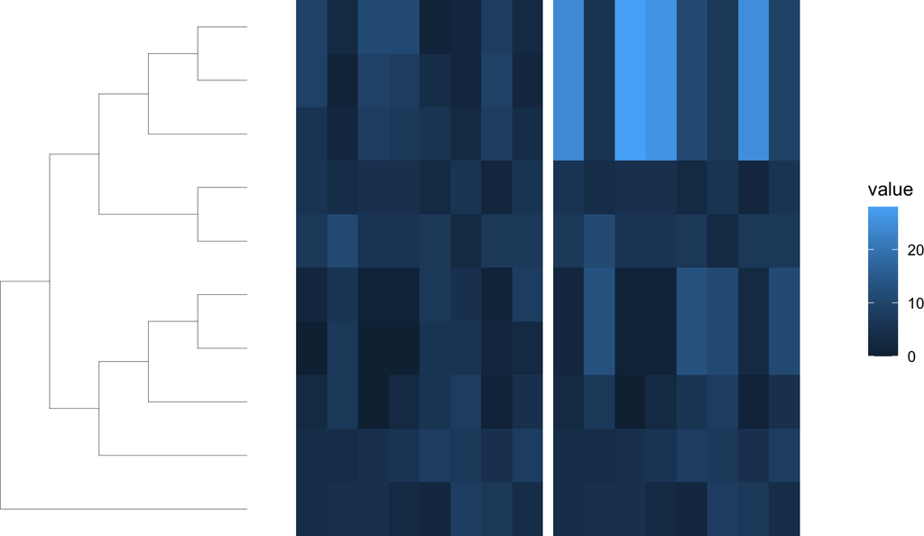

```r
(fig_hm2 <- ggtree(toytree, branch.length = "none", size = 0.1) +
  geom_th_heatmap(th_data = count, name = "hm1", gap = 1) +
  geom_th_heatmap(th_data = agg_count, name = "hm2", gap = 0.2))
```

When the layout of the tree is changed, e.g., `layout = "circular"`, heatmaps will change accordingly.

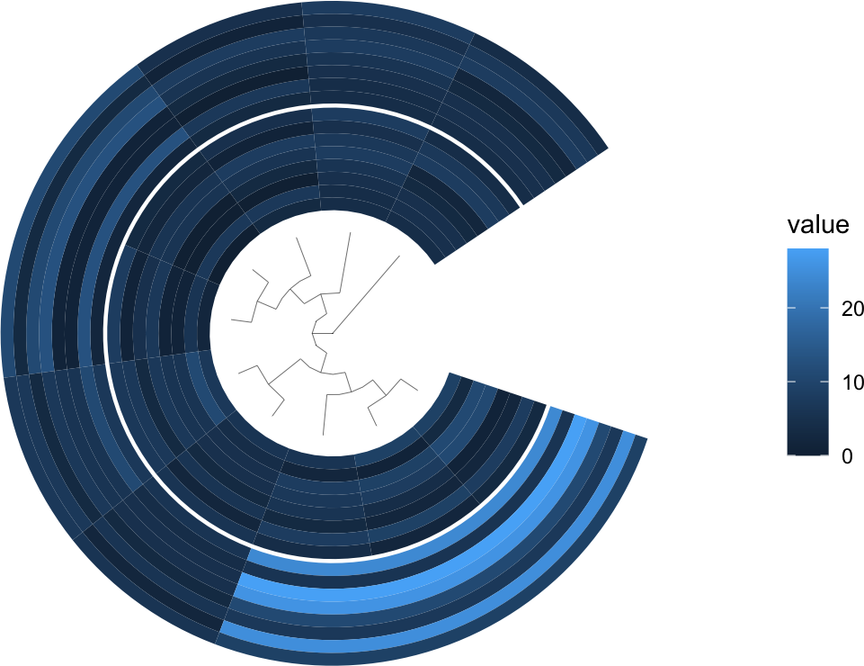

```r
ggtree(toytree, branch.length = "none", size = 0.1,
       layout = "circular") +
  geom_th_heatmap(th_data = count, name = "hm1", gap = 1) +
  geom_th_heatmap(th_data = agg_count, name = "hm2", gap = 0.2)
```

The fill color of heatmap can be changed using `scale_fill_*` in *ggplot2* (e.g., `scale_fill_viridis_c`).

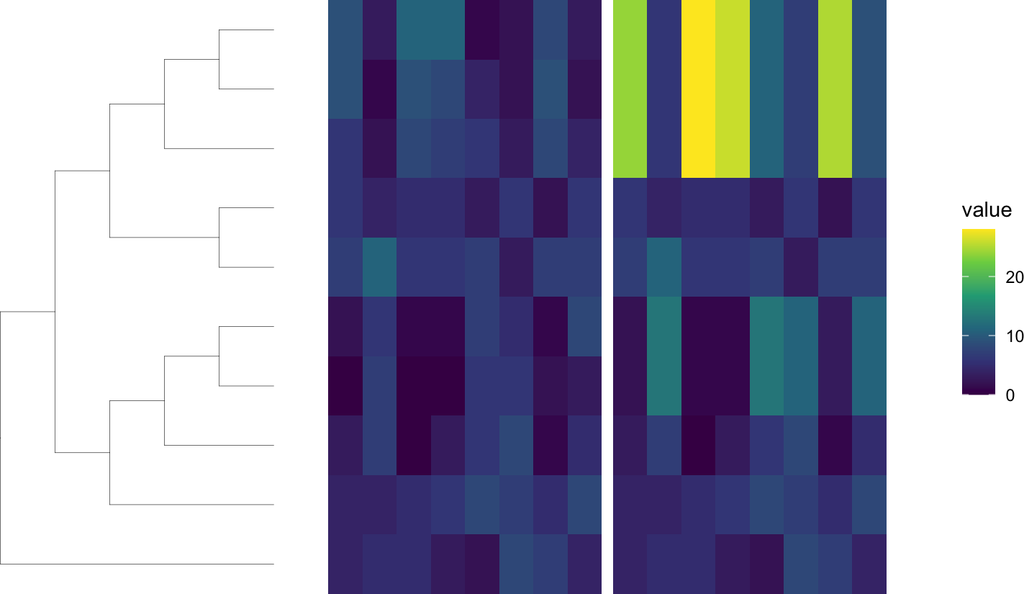

```r
fig_hm2 +
  scale_fill_viridis_c()
```

To use different fill colors for two heatmaps, we could use `new_scale_fill` from *ggnewscale* to separate them.

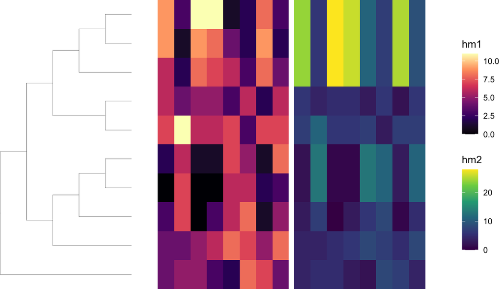

```r
(fig_hm3 <- ggtree(toytree, branch.length = "none", size = 0.1) +
   geom_th_heatmap(th_data = count, name = "hm1", gap = 1) +
   scale_fill_viridis_c(option = "A", name = "hm1") +
   new_scale_fill() +
   geom_th_heatmap(th_data = agg_count, name = "hm2", gap = 0.2) +
   scale_fill_viridis_c(option = "D", name = "hm2")
)
```

# 3 Annotation on the row tree

We are free to use functions from *ggtree* to decorate the tree.

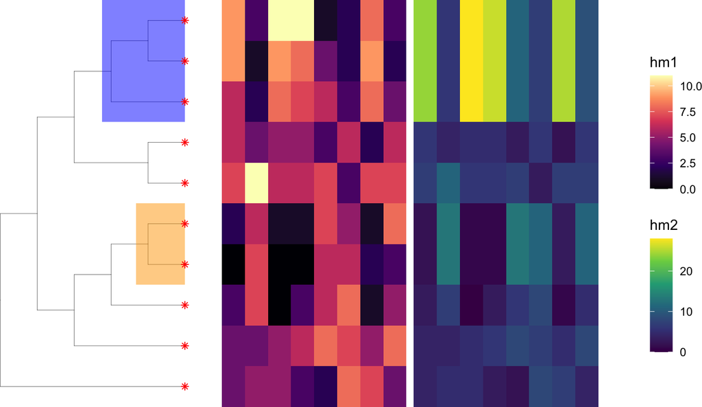

```r
(fig_hm3 <- fig_hm3 +
  geom_hilight(node = 18, fill = "blue", alpha = 0.5) +
  geom_hilight(node = 15, fill = "orange", alpha = 0.5) +
  geom_tippoint(color = "red", shape = 8))
```

# 4 Annotation on the heatmap

## 4.1 Display row and column names

Row or column names are added to the heatmap using `geom_th_text`. When `side = left` or `side = right`, row names are added. When `side = top` or `side= bottom`, column names are added. `nudge_x` and `nudge_y` are used to adjust the text horizontally and vertically, respectively. We can use `name` to select the heatmap. More arguments like `size`, `color` that are accepted by `ggplot2::geom_text` are also recognized by `geom_th_text`.

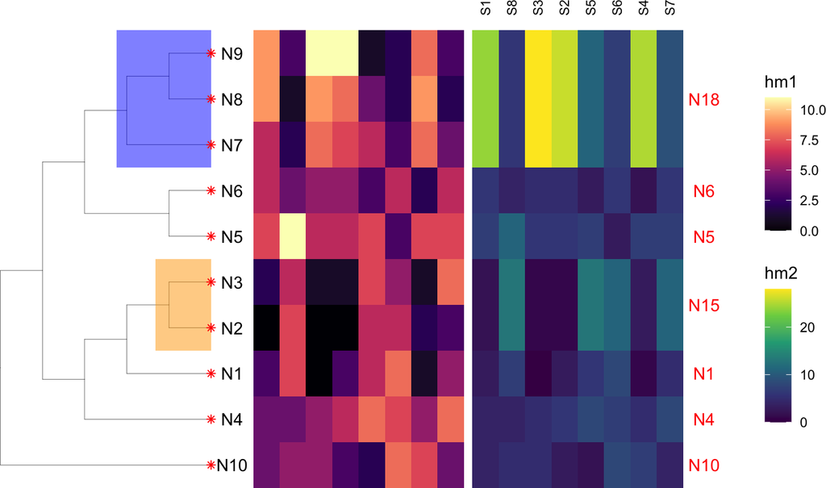

```r
fig_hm3 +
  geom_th_text(name = "hm1", side = "left", nudge_x = -0.5) +
  geom_th_text(name = "hm2", side = "right", nudge_x = 0.5,
               color = "red") +
  geom_th_text(name = "hm2", side = "top", nudge_y = 0.5,
               angle = 90, size = 3)
```

A new data can be provided in the layer `geom_th_text` to customize the display of row names. For example, only rows in groups `B` and `C` have names displayed, and the text color is decided by the `group`.

```r
(df_row <- data.frame(rowLab = rownames(count),
                     group = c("A", "B", "B", "A", "A",
                               "A", "C", "C", "C", "A")))
```

```
##    rowLab group
## 1      N1     A
## 2      N2     B
## 3      N3     B
## 4      N4     A
## 5      N5     A
## 6      N6     A
## 7      N7     C
## 8      N8     C
## 9      N9     C
## 10    N10     A
```

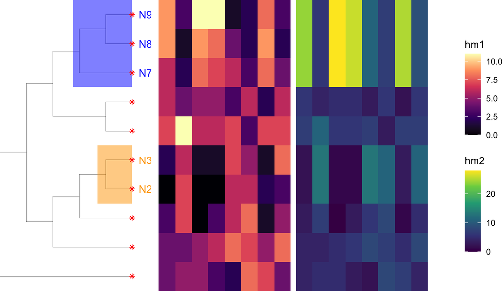

```r
fig_hm3 +
  geom_th_text(th_data = df_row,
               aes(subset = group %in% c("B", "C"), color = group),
               name = "hm1", side = "left", nudge_x = -0.5,
               show.legend = FALSE) +
  scale_color_manual(values = c("B" = "orange",
                                "C" = "blue"))
```

## 4.2 Display row and column titles

The row or column title of heatmap can be added using `geom_th_title`.

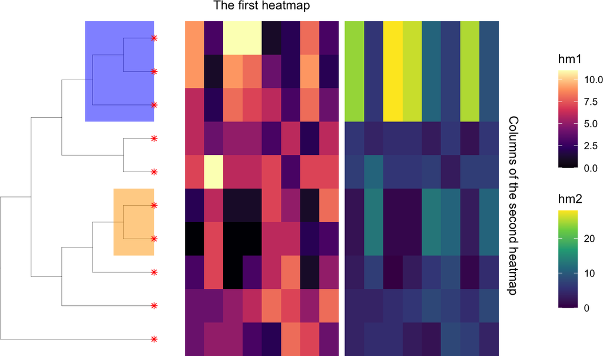

```r
fig_hm3 +
  geom_th_title(name = "hm1", side = "top",
                label = "The first heatmap", nudge_y = -0.5) +
  geom_th_title(name = "hm2", side = "right",
                label = "Columns of the second heatmap",
                angle = -90, nudge_x = -0.5)
```

## 4.3 Display entry values

`geom_th_addvalue` is used to display entry values of the heatmap. We can customize the text using arguments, e.g., `color`, `size`, that are accepted by `geom_text`.

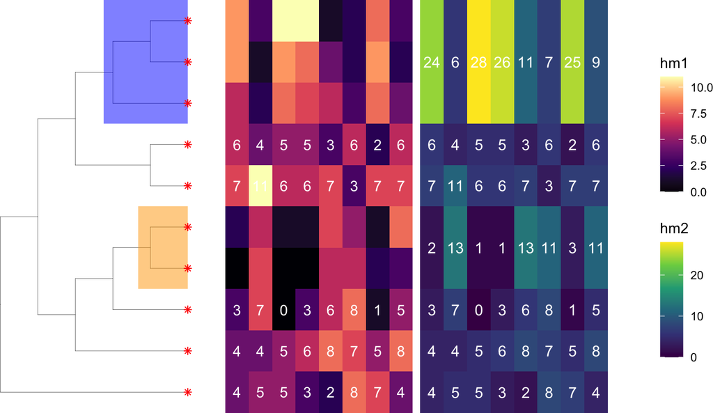

```r
fig_hm3 +
  geom_th_addvalue(name = "hm2", color = "white", size = 4) +
  geom_th_addvalue(th_data = df_row,
                   aes(subset = group %in% "A"),
                   color = "white",
                   name = "hm1", show.legend = FALSE)
```

## 4.4 Display barplots

We can add barplots to annotate rows or columns of heatmap. The provided data should include a column named as `colLab` to store the column name. This column is used internally to align barplot with columns of heatmap. The barplot is filled according to the `aes(x = colLab, y = obs, fill = Category)`. The barplot is put on the top of the heatmap `side = "top"`. The gap between the barplot and the heatmap is `gap = 0.2`. The relative height of the barplot is `rel_height = 0.1` compared to the height of the row tree.

```r
(col_bar <- data.frame(colLab = rep(colnames(count), 2),
                       obs = c(1:8, rep(5, 8)),
                       Category = rep(LETTERS[1:2], each = 8)))
```

```
##    colLab obs Category
## 1      S1   1        A
## 2      S8   2        A
## 3      S3   3        A
## 4      S2   4        A
## 5      S5   5        A
## 6      S6   6        A
## 7      S4   7        A
## 8      S7   8        A
## 9      S1   5        B
## 10     S8   5        B
## 11     S3   5        B
## 12     S2   5        B
## 13     S5   5        B
## 14     S6   5        B
## 15     S4   5        B
## 16     S7   5        B
```

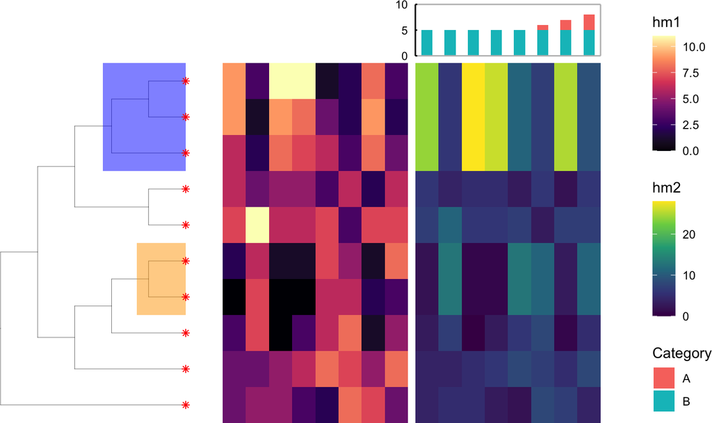

```r
(fig_hm4 <- fig_hm3 +
  new_scale_fill() +
  geom_th_bar(name = "hm2",
              th_data = col_bar,
              aes(x = colLab, y = obs, fill = Category),
              side = "top",
              gap = 0.2,
              rel_height = 0.1))
```

Similarly, we can add a barplot to annotate rows as below. The data `row_bar` now provides a column named as `rowLab` instead of `colLab` in `col_bar`. The width of the barplot is adapted via `rel_width` in `geom_th_bar`. We put the barplot either on `side = left` or `side = right` to annotate the heatmap.

```r
(row_bar <- data.frame(rowLab = rep(rownames(agg_count), 2),
                       obs = c(1:7, rep(5, 7)),
                       Category = rep(LETTERS[1:2], each = 7)))
```

```
##    rowLab obs Category
## 1      N1   1        A
## 2     N15   2        A
## 3      N4   3        A
## 4      N5   4        A
## 5      N6   5        A
## 6     N18   6        A
## 7     N10   7        A
## 8      N1   5        B
## 9     N15   5        B
## 10     N4   5        B
## 11     N5   5        B
## 12     N6   5        B
## 13    N18   5        B
## 14    N10   5        B
```

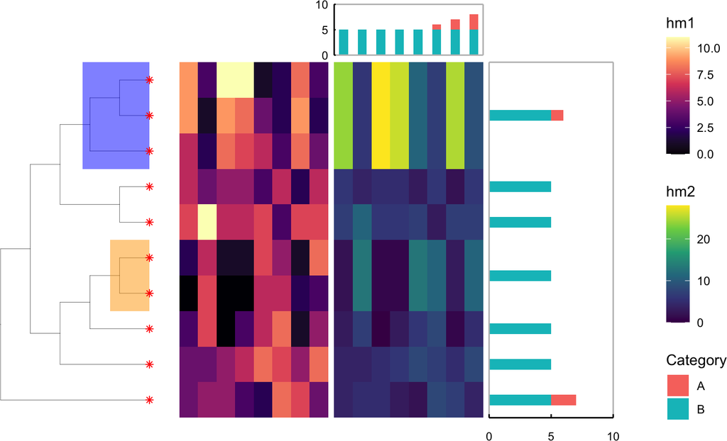

```r
fig_hm4  +
  new_scale_fill()+
  geom_th_bar(name = "hm2",
              th_data = row_bar,
              aes(y = colLab, x = obs, fill = Category),
              side = "right",
              gap = 0.2,
              rel_width = 0.5)
```

# 5 Real case

```r
data("Oral")
names(Oral)
```

```
## [1] "count_table" "taxo_table"  "meta_sample" "phylo_tree"  "taxo_tree"
```

```r
# trees: phylogenetic/taxonomic tree
phylo_tree <- Oral$phylo_tree
taxo_tree <- Oral$taxo_tree

# Counts: count_table is already in CPM scale
count_table <- Oral$count_table
count_log <- log10(count_table + 1)


Fig <- ggtree(taxo_tree, branch.length = "none") +
  geom_th_heatmap(name = "logCPM",
                  th_data = count_log,
                  cluster_column = TRUE,
                  size_coltree = 0.3,
                  color_coltree = "black",
                  rel_height_coltree = 0.3,
                  gap_coltree = 3) +
  scale_fill_viridis_c(option = "D", name = "logCPM")
```

We annotate samples with the body site.

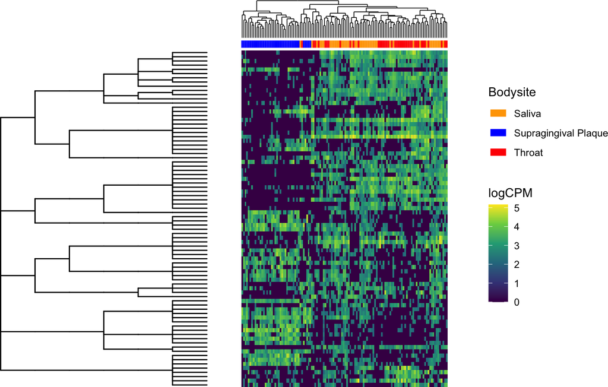

```r
df_sample <- Oral$meta_sample %>%
  mutate(colLab = rownames(Oral$meta_sample),  # column names
         Bodysite = HMP_BODY_SUBSITE) %>%
  select(colLab, Bodysite)

 Fig +
   geom_th_segment(th_data = df_sample,
                   aes(color = Bodysite),
                   side = "top", size = 3,
                   nudge_y = 1.5) +
   scale_color_manual(values = c("Saliva" = "orange",
                                 "Supragingival Plaque" = "blue",
                                 "Throat" = "red"))
```

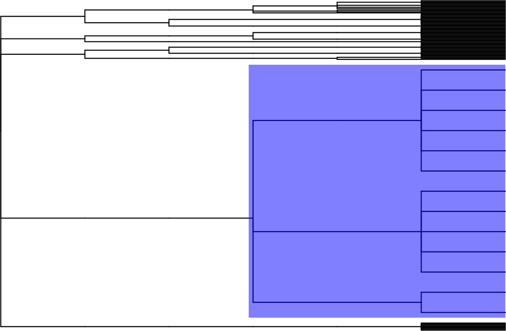

```r
taxo_table <- Oral$taxo_table

node_a <- nodeid(tree = taxo_tree, label = "ORDER:Actinomycetales")
no_a <- setdiff(taxo_table$ORDER, "ORDER:Actinomycetales")
node_b <- nodeid(tree = taxo_tree, label = paste0("ORDER:", no_a))

(fig_tree <- ggtree_th(taxo_tree, branch.length = "none",
                       node = c(node_a, node_b),
                       scale_y = c(20, rep(0.1, length(node_b)))) +
                geom_hilight(node  = node_a, fill = "blue",
                             alpha =  0.5) )
```

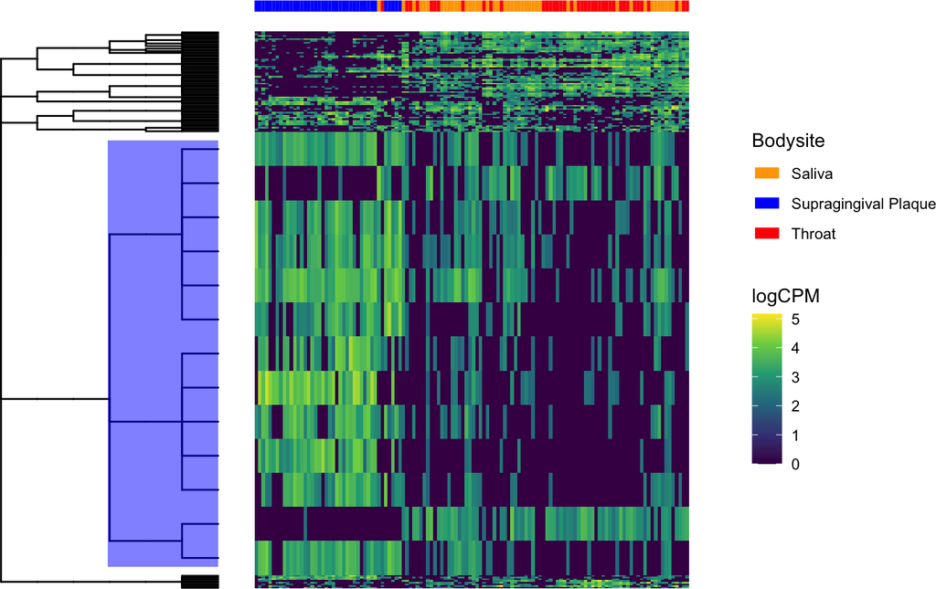

```r
# fig_0 <- ggtree(taxo_tree, branch.length = "none")
# # node_ab <- setdiff(c(node_a, node_b), 104)
# # n_ab <- c(3, rep(0.1, length(node_b)-1))
#
# node_ab <- setdiff(node_b, 104)
# n_ab <- rep(0.1, length(node_b)-1)
#
# for (i in seq_along(node_ab)) {
#   fig_0 <- fig_0 %>% scaleClade(node = node_ab[i], scale = n_ab[i])
# }
#
#
# fig_0 +
#   geom_hilight(node  = node_a, fill = "blue",
#                              alpha =  0.5)
# fig_0 +
#   geom_th_heatmap(name = "logCPM",
#                   th_data = count_log,
#                   cluster_column = TRUE,
#                   show_coltree = FALSE,
#                   rel_width = 2) +
#   scale_fill_viridis_c(option = "d", name = "logCPM") +
#   geom_th_segment(th_data = df_sample,
#                    aes(color = Bodysite),
#                    side = "top", size = 3,
#                    nudge_y = 1.5) +
#    scale_color_manual(values = c("Saliva" = "orange",
#                                  "Supragingival Plaque" = "blue",
#                                  "Throat" = "red"))

fig_tree +
  geom_th_heatmap(name = "logCPM",
                  th_data = count_log,
                  cluster_column = TRUE,
                  show_coltree = FALSE,
                  rel_width = 2) +
  scale_fill_viridis_c(option = "d", name = "logCPM") +
  geom_th_segment(th_data = df_sample,
                   aes(color = Bodysite),
                   side = "top", size = 3,
                   nudge_y = 1.5) +
   scale_color_manual(values = c("Saliva" = "orange",
                                 "Supragingival Plaque" = "blue",
                                 "Throat" = "red"))
```